# Different-Hospital First Readmission and Subsequent All-Cause Admission After Heart Failure Hospitalization

A retrospective cohort study using the 2016–2022 Nationwide Readmissions Database

## Abstract

### Background

Hospital destination may be associated with outcomes after a heart failure readmission.

### Objectives

To evaluate the association between different-hospital first readmission and a composite of death during that readmission or subsequent all-cause inpatient admission after live discharge.

### Methods

We studied adults with a principal-diagnosis heart failure discharge in January through October and a first all-cause readmission within 30 days in the 2016–2022 Nationwide Readmissions Database. Exposure was readmission at the same versus a different hospital. The primary outcome was death during the first readmission or, among survivors, readmission within 30 days after discharge. Survey-weighted regression and design-based standardization estimated adjusted risks and risk differences.

### Results

Among 518,986 eligible first readmissions (509,293 in the complete-case adjusted analysis), the adjusted composite risk was 35.6% (95% CI, 35.5–35.8) after same-hospital and 37.6% (95% CI, 37.3–38.0) after different-hospital readmission; the risk difference was +2.00 percentage points (95% CI, +1.64 to +2.36) and the risk ratio was 1.06, 95% CI 1.05–1.07. The adjusted risks were 6.1% (95% CI, 6.0–6.2) versus 7.4% (95% CI, 7.2–7.6) for in-hospital death (risk ratio, 1.21, 95% CI 1.17–1.24) and 31.5% (95% CI, 31.3–31.6) versus 32.7% (95% CI, 32.3–33.0) for subsequent readmission among survivors (risk difference, +1.20 percentage points (95% CI, +0.84 to +1.56); risk ratio, 1.04, 95% CI 1.03–1.05). Different-hospital readmission increased from 20.7% in 2016 to 23.2% in 2022.

### Conclusions

Different-hospital first readmission was associated with a modestly higher composite risk, with the largest relative association for death during the first readmission. These findings are associational and do not establish an effect of hospital destination.

## Introduction

Heart failure hospitalization is often followed by additional inpatient care. Prior studies have compared outcomes for patients readmitted to the original or a different hospital [1,2], and national studies have described repeated admissions after heart failure hospitalization [4]. Studies of interhospital care fragmentation provide broader context [3,5]. This study extends that literature by examining the first all-cause readmission after a heart failure admission and the subsequent inpatient course. A different hospital is an administrative site distinction in the Nationwide Readmissions Database; it does not establish fragmented clinician care, information exchange, transfer appropriateness, or care quality.

## Methods

### Data source and cohort

We used the 2016–2022 Healthcare Cost and Utilization Project Nationwide Readmissions Database (NRD), a weighted sample of inpatient stays that supports patient linkage within a state and calendar year. We identified adults aged 18 years or older discharged from January through October after a principal-diagnosis heart failure admission. One eligible index admission was retained per patient-year. Sequential exclusions were age younger than 18 years; index in-hospital death or unknown status; transfer to acute care; discharge against medical advice; non-resident status; missing linkage, hospital identifier, or length of stay; same-day or rehabilitation events; and later ineligible index admissions. We then selected the first all-cause readmission within 30 days; heart failure was not required as the readmission diagnosis. The earliest event was selected by days from index discharge, with ties on the same NRD day resolved by the NRD event key; ties were counted once per year (Table 0). The first linked event defined eligibility: if it was same-day-collapsed, a rehabilitation transfer, or an acute-care transfer, the index admission was excluded, with no search for a later qualifying event. Patients entered the cohort whether or not they survived that readmission. To keep 30-day follow-up within the same calendar year, the first-readmission discharge month had to be November or earlier; this rule applied symmetrically to known-status deaths and live discharges, excluding both after-November survivors and deaths.

### Exposure and outcome hierarchy

The exposure was a first all-cause readmission at a different hospital versus the index hospital, determined by the NRD hospital identifier within year. The primary outcome was a composite of in-hospital death during the first readmission or, among patients discharged alive, any inpatient readmission within 30 days of that discharge. The primary denominator included first readmissions with known vital status. Key secondary outcomes were in-hospital death during the first readmission and subsequent readmission among patients discharged alive. Other secondary outcomes were first-readmission length of stay and hospitalization cost, HF-coded subsequent readmission, and non-elective-coded subsequent readmission.

### Covariates and statistical analysis

The congestive heart failure comorbidity indicator was omitted because nearly all patients had it. The primary adjustment set included discharge year; age; sex; expected payer; ZIP-code income quartile; county urban–rural category; index-hospital bed size, location/teaching status, ownership, and annual heart failure volume; index length of stay; index discharge disposition; All Patient Refined Diagnosis Related Groups (APR-DRG) severity; Elixhauser comorbidities; days from index discharge to first readmission (1–7, 8–14, or 15–30); and any earlier hospitalization in the calendar year when derivable. Annual heart-failure volume counted all principal-diagnosis HF discharges across all months and ages within each hospital-year; quartiles were assigned once per unique hospital-year, with tied volumes ordered by hospital identifier when a cutpoint split a tie. Age and log(1+index length of stay) used natural splines with boundary knots at the 5th/95th percentiles and internal knots at the 35th/65th percentiles in the primary complete-case population; numeric knots are listed in Table S4. Adjustment was restricted to information measured before the first-readmission destination; first-readmission length of stay, severity, procedures, and receiving-hospital characteristics were excluded from the primary model.

We used survey-weighted logistic regression with year-specific strata and primary sampling units, nested design handling, and domain estimation. Survey-design delta-method standardization estimated adjusted risks and 95% confidence intervals. The primary contrast was the risk difference (different hospital minus same hospital), reported in percentage points; the risk ratio was secondary. We used overlap weights from a propensity score based on the primary covariates, multiplied by the survey weight, as a sensitivity analysis and summarized covariate balance before and after weighting. Prespecified subgroup estimates were examined by age, sex, payer, rurality, index-hospital location/teaching category, and first-readmission cause; exposure-by-subgroup Wald tests assessed interaction. These subgroup analyses were exploratory and hypothesis-generating. Annual destination proportions and outcome contrasts were assessed with year as a continuous term for trend tests.

Hospitalization cost was derived as total charges multiplied by the NRD cost-to-charge ratio, then inflated to 2022 US dollars using the Consumer Price Index for medical care. Missing total charges and invalid cost-to-charge ratios were excluded from cost analyses; charge-missing exclusions are reported in Table 4. Length of stay, including zero-day stays, and cost were modeled with survey-weighted quasi-Poisson regression using a log link; adjusted ratios of means and 95% confidence intervals are reported with weighted means and medians. Missing covariate data were preserved in the primary data and handled by complete-case analysis; the missing-category sensitivity coded categorical missing values as Unknown. Missingness by variable and exposure, and complete-case inclusion by exposure and year, are summarized in the supplement. The elective-readmission sensitivity excluded records coded elective and records with missing elective status; its denominator is reported in Table 6. First-readmission cause in the destination-predictor model is a concurrent correlate measured during that stay, not an antecedent predictor. Cells with counts of 10 or fewer are shown as ≤10; associated percentages and the minimum complementary cells are suppressed. All analyses use deidentified administrative data and report associations in a selected cohort; they do not estimate causal effects.

## Results

### Cohort and baseline characteristics

The analytic cohort included 518,986 first readmissions: 407,149 same-hospital and 111,837 different-hospital readmissions. The primary complete-case model included 400,239 same-hospital and 109,054 different-hospital readmissions. Table 0 presents each sequential exclusion, including unknown first-readmission vital status, discharge after November, same-day events, rehabilitation, acute-care transfer, and complete-case loss. Earliest-readmission date ties resolved by the NRD event key occurred 0 times across the seven years.

Patients with different-hospital readmission were younger, more often covered by Medicaid, more often lived in non-metropolitan counties, and more often had their index HF admission at a small hospital. Table 1 summarizes the analytic cohort using survey-weighted percentages, unweighted counts, and standardized mean differences; no baseline significance tests were performed.

### Primary and secondary outcomes

The adjusted primary composite risks were 35.6% (95% CI, 35.5–35.8) after same-hospital and 37.6% (95% CI, 37.3–38.0) after different-hospital readmission, with a risk difference of +2.00 percentage points (95% CI, +1.64 to +2.36) and risk ratio of 1.06, 95% CI 1.05–1.07. In-hospital death risks were 6.1% (95% CI, 6.0–6.2) versus 7.4% (95% CI, 7.2–7.6); the adjusted risk difference was +1.26 percentage points (95% CI, +1.06 to +1.45) and risk ratio was 1.21, 95% CI 1.17–1.24. Among patients discharged alive, subsequent admission risks were 31.5% (95% CI, 31.3–31.6) versus 32.7% (95% CI, 32.3–33.0), with a risk difference of +1.20 percentage points (95% CI, +0.84 to +1.56) and risk ratio of 1.04, 95% CI 1.03–1.05.

The adjusted HF-coded subsequent-readmission risk difference was +0.18 percentage points (95% CI, -0.07 to +0.42) (P = 0.157). The adjusted risk difference for non-elective-coded subsequent readmission was +0.94 percentage points (95% CI, +0.59 to +1.29). Unadjusted estimates and denominators are shown in Table 2; adjusted estimates and outcome-specific analysis populations are shown in Table 3.

### Resource use, causes, and additional analyses

Table 4 reports survey-weighted median (IQR) and mean resource use by exposure, the unweighted and weighted denominators, and adjusted ratios of means. Zero-day stays were included in length-of-stay analyses; missing charges and invalid cost-to-charge ratios were excluded from cost analyses. AKI denotes acute kidney injury and GI denotes gastrointestinal. First-readmission causes are assigned once using the ordered, mutually exclusive ICD-10-CM map in Table S8; pneumonia is classified under respiratory disease and R06 under respiratory/chronic obstructive pulmonary disease (COPD).

Subgroup risk differences and interaction tests are shown in Table 5b; these analyses are exploratory and hypothesis-generating. Sensitivity risk differences ranged from +1.94 to +2.32 percentage points. After overlap weighting, the maximum absolute standardized difference among propensity-model covariates was 0.004; the weighted risk difference is shown in Table 6. Annual weighted different-hospital readmission increased from 20.7% in 2016 to 23.2% in 2022 (P < 0.001); the trend in annual risk differences was P = 0.070. Figure 4 shows annual estimates.

## Discussion

In this contemporary national cohort, different-hospital first readmission was associated with a modestly higher adjusted risk of the primary composite. Prior HF studies also reported worse outcomes for patients readmitted to a different hospital, particularly mortality and length of stay during that encounter [1,2]. The strongest relative association in this analysis was with in-hospital death during the first readmission (adjusted risk ratio, 1.21, 95% CI 1.17–1.24); the subsequent-admission difference after live discharge was +1.20 percentage points (95% CI, +0.84 to +1.56). HF-coded subsequent readmission showed an adjusted risk difference of +0.18 percentage points (95% CI, -0.07 to +0.42). Different-hospital readmission increased over the study period, from 20.7% to 23.2%. Subgroup estimates and interaction tests are shown in Table 5b and require confirmation.

These findings should be interpreted as associations. The cohort was selected on experiencing a first readmission, and the post-discharge outcome additionally conditions on live discharge. Conditioning on these events can introduce selection bias. NRD hospital identifiers capture site, not clinician continuity or information exchange, and the database does not measure distance, referral, ambulance routing, patient preference, or bed capacity. NRD captures inpatient stays within a state and calendar year and does not observe out-of-hospital death. Residual confounding and complete-case selection may also affect estimates. The results do not establish that a different destination causes an adverse outcome or that changing destination would prevent one.

## Conclusion

Among adults with a heart failure index admission followed by a first all-cause readmission, readmission at a different hospital was associated with a modestly higher risk of the primary composite, with the strongest relative association observed for in-hospital death during the first readmission. These selected-cohort estimates describe associations and do not establish a causal effect of hospital destination.

## Tables and figures

### Table 0. Cohort selection

Unweighted remaining and excluded counts and weighted population estimates at each sequential cohort step. Same-hospital and different-hospital complete-case losses are shown separately.

| Step | Cohort stage | Excluded, unweighted n | Remaining, unweighted n | Remaining, weighted n |
| --- | --- | --- | --- | --- |
| 1 | HF principal discharges, January–October | — | 3,829,973 | 7,010,185 |
| 2 | Excluded: age <18 | 2,477 | 3,827,496 | 7,001,851 |
| 3 | Excluded: index death or unknown status | 115,485 | 3,712,011 | 6,793,058 |
| 4 | Excluded: transfer out to acute care | 36,039 | 3,675,972 | 6,727,150 |
| 5 | Excluded: discharge against medical advice | 77,907 | 3,598,065 | 6,591,823 |
| 6 | Excluded: nonresident | 134,843 | 3,463,222 | 6,318,836 |
| 7 | Excluded: missing linkage, hospital, or length of stay | 75 | 3,463,147 | 6,318,702 |
| 8 | Excluded: same-day or rehabilitation event | 69,514 | 3,393,633 | 6,188,645 |
| 9 | Retained: first eligible index per patient-year | 707,738 | 2,685,895 | 4,902,849 |
| 10 | Retained: first all-cause readmission within 30 days | 2,139,466 | 546,429 | 994,797 |
| 11 | Excluded: unknown first-readmission vital status | 152 | 546,277 | 994,549 |
| 12 | Excluded: first readmission discharged after November | 1,809 | 544,468 | 991,304 |
| 13 | Excluded: same-day-collapsed first event | 20,229 | 524,239 | 953,828 |
| 14 | Excluded: first-readmission rehabilitation transfer | 0 | 524,239 | 953,828 |
| 15 | Excluded: first-readmission transfer to acute care | 5,253 | 518,986 | 944,290 |
| 16 | Same-hospital first readmission | — | 407,149 | 741,058 |
| 17 | Different-hospital first readmission | — | 111,837 | 203,232 |
| 18 | Complete-case cohort: same hospital | 6,910 | 400,239 | 729,635 |
| 19 | Complete-case cohort: different hospital | 2,783 | 109,054 | 198,803 |

*Note.* Tied earliest readmission dates, resolved by the NRD event key and counted once per year: 0.

### Figure 1. Cohort flow

The first readmission is all-cause. The primary composite includes death during that readmission or, after live discharge, any inpatient admission within 30 days. Table 0 gives the sequential exclusions and counts.

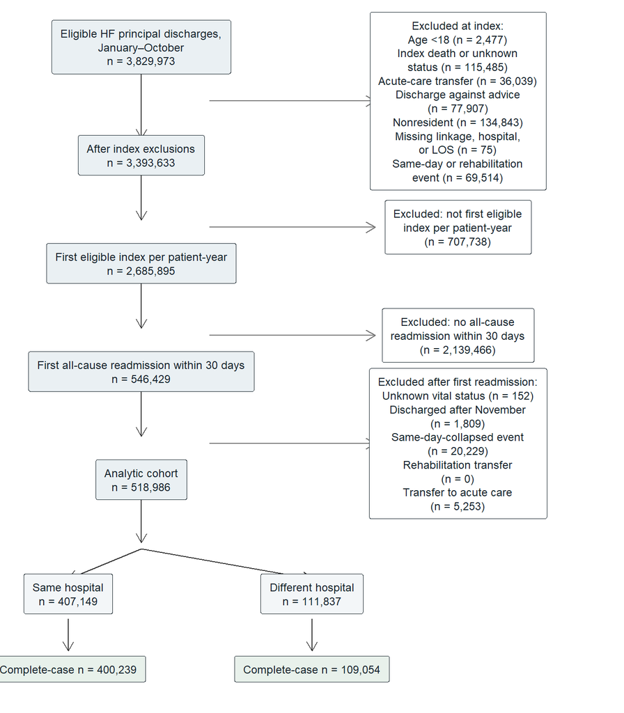

Figure 1: CONSORT-style construction of the heart-failure cohort. Side boxes list exclusions and unweighted counts; the final branches show complete-case sample sizes.

### Table 1. Baseline characteristics

Values are unweighted counts with survey-weighted percentages, except continuous characteristics, which are medians and interquartile ranges. Standardized mean differences describe balance; no P values are reported. Counts of 1–10 are shown as ≤10; * denotes complementary suppression. Percentages use nonmissing survey-weighted denominators.

| Characteristic | Category | Overall | Same hospital | Different hospital | Standardized mean difference |
| --- | --- | --- | --- | --- | --- |
| Age, y | Median (IQR) | 73 (63-83) | 74 (63-83) | 72 (61-81) | -0.159 |
| Sex | Female | 249,243 (48.2%) | 197,774 (48.7%) | 51,469 (46.4%) | 0.046 |
|  | Male | 269,743 (51.8%) | 209,375 (51.3%) | 60,368 (53.6%) |  |
| Expected payer | Medicare | 399,008 (77.1%) | 316,768 (78.0%) | 82,240 (74.0%) | 0.102 |
|  | Medicaid | 58,832 (11.0%) | 43,014 (10.3%) | 15,818 (13.5%) |  |
|  | Private | 41,915 (8.2%) | 32,601 (8.1%) | 9,314 (8.4%) |  |
|  | Other | 18,679 (3.7%) | 14,353 (3.6%) | 4,326 (4.1%) |  |
| ZIP-code income quartile | Quartile 1 (lowest income) | 165,371 (34.1%) | 126,422 (33.3%) | 38,949 (37.3%) | 0.086 |
|  | Quartile 2 | 138,528 (27.5%) | 109,096 (27.6%) | 29,432 (27.1%) |  |
|  | Quartile 3 | 118,574 (22.3%) | 94,689 (22.8%) | 23,885 (20.7%) |  |
|  | Quartile 4 (highest income) | 90,972 (16.0%) | 72,627 (16.3%) | 18,345 (14.8%) |  |
| County urban–rural category | Metro | 447,591 (84.4%) | 355,267 (85.5%) | 92,324 (80.2%) | 0.141 |
|  | Non-metro | 67,757 (15.6%) | 49,673 (14.5%) | 18,084 (19.8%) |  |
| Index-hospital bed size | Small | 94,958 (19.3%) | 67,858 (17.5%) | 27,100 (25.6%) | 0.199 |
|  | Medium | 149,640 (27.9%) | 116,301 (27.7%) | 33,339 (28.8%) |  |
|  | Large | 274,388 (52.8%) | 222,990 (54.8%) | 51,398 (45.5%) |  |
| Hospital location/teaching status | Nonteaching urban | 119,815 (21.5%) | 90,646 (20.7%) | 29,169 (24.3%) | 0.143 |
|  | Teaching urban | 357,007 (68.5%) | 285,236 (69.9%) | 71,771 (63.2%) |  |
|  | Rural | 42,164 (10.0%) | 31,267 (9.4%) | 10,897 (12.4%) |  |
| Index-hospital ownership | Government | 56,042 (10.3%) | 43,099 (10.1%) | 12,943 (11.1%) | 0.108 |
|  | Private nonprofit | 385,110 (75.3%) | 306,434 (76.3%) | 78,676 (71.6%) |  |
|  | Private for-profit | 77,834 (14.4%) | 57,616 (13.6%) | 20,218 (17.4%) |  |
| Annual index-hospital HF volume | Q1 | 4,260 (1.0%) | 2,149 (0.7%) | 2,111 (2.3%) | 0.272 |
|  | Q2 | 31,311 (6.9%) | 19,517 (5.5%) | 11,794 (12.0%) |  |
|  | Q3 | 122,662 (23.7%) | 91,856 (22.7%) | 30,806 (27.3%) |  |
|  | Q4 | 360,753 (68.4%) | 293,627 (71.2%) | 67,126 (58.3%) |  |
| Index length of stay, d | Median (IQR) | 4 (3-7) | 4 (3-7) | 4 (3-7) | -0.006 |
| Index discharge disposition | Routine discharge | * | 195,395 (48.6%) | * | 0.118 |
|  | Other facility | 105,739 (20.6%) | 80,800 (20.1%) | 24,939 (22.4%) |  |
|  | Home health | 160,593 (30.1%) | 130,954 (31.2%) | 29,639 (25.9%) |  |
|  | Missing/unknown | ≤10 | 0 (0.0%) | ≤10 |  |
| All Patient Refined Diagnosis Related Groups (APR-DRG) severity | Minor | 24,768 (4.8%) | 18,594 (4.5%) | 6,174 (5.6%) | 0.049 |
|  | Unknown | ≤10 | ≤10 | ≤10 |  |
|  | Moderate | 156,994 (30.3%) | 121,645 (29.9%) | 35,349 (31.7%) |  |
|  | Major | * | * | * |  |
|  | Extreme | 82,924 (15.9%) | 65,310 (16.0%) | 17,614 (15.5%) |  |
| Days to first readmission | 1–7 | 159,007 (30.6%) | 123,257 (30.2%) | 35,750 (31.9%) | 0.037 |
|  | 8–14 | 136,732 (26.3%) | 107,829 (26.5%) | 28,903 (25.8%) |  |
|  | 15–30 | 223,247 (43.1%) | 176,063 (43.3%) | 47,184 (42.3%) |  |
| Earlier hospitalization in calendar year | No | 316,870 (61.0%) | 249,628 (61.2%) | 67,242 (60.2%) | 0.020 |
|  | Yes | 202,116 (39.0%) | 157,521 (38.8%) | 44,595 (39.8%) |  |

### Table 2. Unadjusted outcomes

Event counts are unweighted; risks and 95% confidence intervals are survey-weighted. Denominators differ by outcome and are shown for each row.

| Outcome | First-readmission hospital | Events, unweighted n | Denominator, unweighted n | Weighted risk (95% CI) |
| --- | --- | --- | --- | --- |
| Death during first readmission or subsequent admission | Same hospital | 145,679 | 407,149 | 35.7% (95% CI, 35.5–35.8) |
| Death during first readmission or subsequent admission | Different hospital | 42,730 | 111,837 | 37.9% (95% CI, 37.6–38.2) |
| In-hospital death during first readmission | Same hospital | 25,364 | 407,149 | 6.1% (95% CI, 6.0–6.2) |
| In-hospital death during first readmission | Different hospital | 8,222 | 111,837 | 7.2% (95% CI, 7.0–7.4) |
| 30-day readmission after live discharge | Same hospital | 120,315 | 381,785 | 31.5% (95% CI, 31.3–31.6) |
| 30-day readmission after live discharge | Different hospital | 34,508 | 103,615 | 33.1% (95% CI, 32.7–33.4) |
| HF-coded subsequent readmission | Same hospital | 42,749 | 381,785 | 11.2% (95% CI, 11.1–11.3) |
| HF-coded subsequent readmission | Different hospital | 12,093 | 103,615 | 11.6% (95% CI, 11.3–11.8) |
| Non-elective-coded subsequent readmission | Same hospital | 115,562 | 381,696 | 30.1% (95% CI, 29.9–30.3) |
| Non-elective-coded subsequent readmission | Different hospital | 32,843 | 103,592 | 31.4% (95% CI, 31.1–31.7) |

### Table 3. Adjusted outcomes

Adjusted risks were standardized over each outcome-specific analysis population. Risk differences are different hospital minus same hospital and are expressed in percentage points. Risk ratios are secondary measures.

| Outcome | Analysis population, unweighted n | Same-hospital adjusted risk | Different-hospital adjusted risk | Risk difference | Risk ratio | P value |
| --- | --- | --- | --- | --- | --- | --- |
| Primary: death during first readmission or subsequent admission | 509,293 | 35.6% (95% CI, 35.5–35.8) | 37.6% (95% CI, 37.3–38.0) | +2.00 percentage points (95% CI, +1.64 to +2.36) | 1.06, 95% CI 1.05–1.07 | P < 0.001 |
| In-hospital death during first readmission | 509,293 | 6.1% (95% CI, 6.0–6.2) | 7.4% (95% CI, 7.2–7.6) | +1.26 percentage points (95% CI, +1.06 to +1.45) | 1.21, 95% CI 1.17–1.24 | P < 0.001 |
| 30-day readmission after live discharge | 476,177 | 31.5% (95% CI, 31.3–31.6) | 32.7% (95% CI, 32.3–33.0) | +1.20 percentage points (95% CI, +0.84 to +1.56) | 1.04, 95% CI 1.03–1.05 | P < 0.001 |
| HF-coded subsequent readmission | 476,177 | 11.1% (95% CI, 11.0–11.3) | 11.3% (95% CI, 11.1–11.5) | +0.18 percentage points (95% CI, -0.07 to +0.42) | 1.02, 95% CI 0.99–1.04 | P = 0.157 |
| Non-elective-coded subsequent readmission | 476,068 | 30.1% (95% CI, 29.9–30.3) | 31.0% (95% CI, 30.7–31.4) | +0.94 percentage points (95% CI, +0.59 to +1.29) | 1.03, 95% CI 1.02–1.04 | P < 0.001 |

### Figure 2. Adjusted risk differences

Points show adjusted risk differences (different hospital minus same hospital) in percentage points; horizontal lines show 95% confidence intervals. The vertical reference line marks no difference.

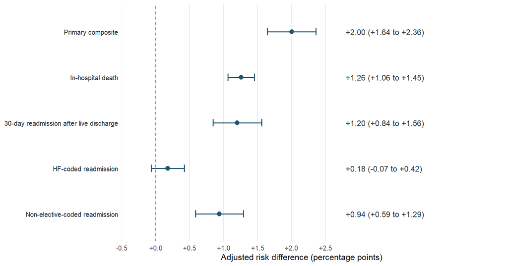

Figure 2: Adjusted risk differences for the primary composite and key secondary outcomes. Estimates are different-hospital minus same-hospital risk, in percentage points; bars show 95% confidence intervals.

### Table 4. First-readmission resource use

Length of stay includes zero-day stays. Cost is total charges multiplied by the NRD cost-to-charge ratio and inflated to 2022 US dollars using CPI-U medical care. Adjusted ratios of means come from survey-weighted quasi-Poisson models with log link; weighted means, medians, and unweighted and weighted denominators are also shown.

| Measure | Same median (IQR) | Different median (IQR) | Same weighted mean | Different weighted mean | Unweighted n | Weighted n | Missing total charges in cost-analysis population (same/different) | Invalid CCR exclusions (same/different) | Adjusted ratio of means (95% CI) | P value |
| --- | --- | --- | --- | --- | --- | --- | --- | --- | --- | --- |
| Length of stay | 4 (3–7) | 5 (3–8) | 6 | 7 | 400,239 / 109,054 | 729,635 / 198,803 | — | — | 1.12, 95% CI 1.11–1.12 | P < 0.001 |
| Cost | $10,258 ($6,179–$18,618) | $12,101 ($7,051–$22,770) | $17,253 | $20,674 | 398,492 / 108,629 | 727,168 / 198,211 | 1,747 / 425 | 0 / 0 | 1.21, 95% CI 1.19–1.23 | P < 0.001 |

*Note.* Cost-model denominators include complete-case stays with nonmissing total charges and a valid CCR; missing-charge counts are within the complete-case cohort, and invalid-CCR exclusions are reported separately. Slash-separated unweighted and weighted denominators are listed as same-hospital/different-hospital.

### Table 5. Cause of first readmission

Counts are unweighted and percentages are survey-weighted.

| Principal-diagnosis group | Same-hospital readmission | Different-hospital readmission |
| --- | --- | --- |
| Heart failure | 154,572 (37.9%) | 37,191 (33.3%) |
| Other cardiovascular | 54,980 (13.5%) | 19,241 (17.2%) |
| Infection/sepsis | 32,802 (7.9%) | 9,468 (8.3%) |
| Renal/AKI | 25,808 (6.4%) | 5,980 (5.4%) |
| Respiratory/COPD | 43,975 (11.0%) | 11,207 (10.2%) |
| GI/bleeding | 25,538 (6.2%) | 6,391 (5.7%) |
| Other | 69,474 (17.0%) | 22,359 (20.0%) |

### Table 5b. Exploratory subgroup analyses

Subgroup risk differences are adjusted estimates. Interaction tests assess whether the association differed across levels; findings are exploratory and hypothesis-generating. Interaction P values are Wald tests on the log-odds scale; subgroup risk differences are standardized risk differences.

| Subgroup | Category | Analysis population, unweighted n | Same-hospital risk | Different-hospital risk | Risk difference | Interaction P value (log-odds scale) |
| --- | --- | --- | --- | --- | --- | --- |
| Age | >=80 | 176,311 | 32.5% | 34.5% | +1.99 percentage points (95% CI, +1.35 to +2.63) | P = 0.369 |
| Age | <65 | 142,151 | 38.2% | 40.5% | +2.32 percentage points (95% CI, +1.69 to +2.96) | P = 0.369 |
| Age | 65-79 | 190,831 | 36.5% | 38.2% | +1.68 percentage points (95% CI, +1.11 to +2.26) | P = 0.369 |
| Sex | Female | 245,921 | 35.2% | 37.0% | +1.82 percentage points (95% CI, +1.30 to +2.34) | P = 0.384 |
| Sex | Male | 263,372 | 36.1% | 38.2% | +2.14 percentage points (95% CI, +1.66 to +2.62) | P = 0.384 |
| Payer | Medicare | 393,839 | 35.5% | 37.5% | +1.95 percentage points (95% CI, +1.54 to +2.37) | P = 0.004 |
| Payer | Medicaid | 55,885 | 39.7% | 42.9% | +3.27 percentage points (95% CI, +2.25 to +4.28) | P = 0.004 |
| Payer | Private | 41,329 | 32.5% | 32.9% | +0.41 percentage points (95% CI, -0.75 to +1.57) | P = 0.004 |
| Payer | Other | 18,240 | 33.6% | 35.2% | +1.65 percentage points (95% CI, -0.10 to +3.41) | P = 0.004 |
| Rurality | Non-metro | 66,429 | 34.3% | 35.6% | +1.28 percentage points (95% CI, +0.40 to +2.15) | P = 0.046 |
| Rurality | Metro | 442,864 | 35.9% | 38.1% | +2.15 percentage points (95% CI, +1.76 to +2.55) | P = 0.046 |
| Hospital location/teaching status | Rural | 41,252 | 33.6% | 35.0% | +1.36 percentage points (95% CI, +0.23 to +2.48) | P = 0.075 |
| Hospital location/teaching status | Nonteaching urban | 117,442 | 35.4% | 36.8% | +1.35 percentage points (95% CI, +0.63 to +2.08) | P = 0.075 |
| Hospital location/teaching status | Teaching urban | 350,599 | 36.0% | 38.3% | +2.30 percentage points (95% CI, +1.86 to +2.75) | P = 0.075 |
| First-readmission cause (HF vs non-HF) | Non-HF | 321,588 | 35.9% | 38.3% | +2.37 percentage points (95% CI, +1.93 to +2.81) | P = 0.004 |
| First-readmission cause (HF vs non-HF) | HF | 187,705 | 35.2% | 36.4% | +1.19 percentage points (95% CI, +0.58 to +1.81) | P = 0.004 |

*Note.* Hospital location/teaching status includes nonteaching urban, teaching urban, and rural hospitals; all three levels are shown.

### Subgroup risk differences

Bars show 95% confidence intervals for adjusted risk differences; zero indicates no difference.

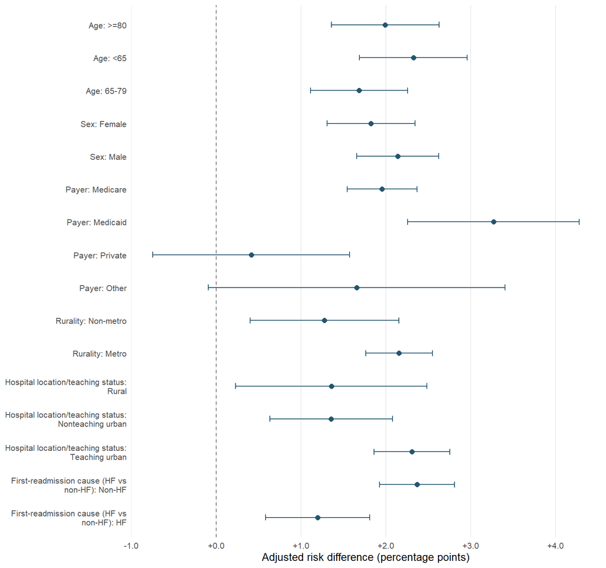

Figure 3: Adjusted risk differences across exploratory subgroups.

### Table 6. Sensitivity analyses

Risk differences are expressed in percentage points. These sensitivity analyses do not remove potential residual confounding or selection bias.

| Analysis | Analysis population, unweighted n | Risk difference | Risk ratio |
| --- | --- | --- | --- |
| January-September index | 468,246 | +2.07 percentage points (95% CI, +1.69 to +2.44) | 1.06, 95% CI 1.05–1.07 |
| Exclude 2020 | 440,296 | +1.94 percentage points (95% CI, +1.55 to +2.33) | 1.05, 95% CI 1.04–1.07 |
| Index principal diagnosis I50-only | 97,222 | +2.32 percentage points (95% CI, +1.48 to +3.16) | 1.07, 95% CI 1.04–1.09 |
| Exclude elective-coded first readmissions | 482,105 | +2.21 percentage points (95% CI, +1.83 to +2.58) | 1.06, 95% CI 1.05–1.07 |
| Add first-readmission diagnosis category (possibly post-exposure) | 509,293 | +2.10 percentage points (95% CI, +1.74 to +2.46) | 1.06, 95% CI 1.05–1.07 |
| Missing-category model; median imputation and missing indicators for age and index LOS | 518,986 | +1.99 percentage points (95% CI, +1.64 to +2.35) | 1.06, 95% CI 1.05–1.07 |
| Propensity-score overlap weights multiplied by NRD survey weights | 509,293 | +2.01 percentage points (95% CI, +1.65 to +2.38) | 1.06, 95% CI 1.05–1.07 |

### Table 7. Characteristics associated with different-hospital first readmission

Odds ratios are associational and describe measured characteristics associated with hospital destination. Estimates are suppressed for unknown index discharge disposition and unknown APR-DRG severity; the congestive-heart-failure indicator was excluded from this model because it was structurally constant. First-readmission cause is measured during the destination stay; cause-stratified analyses describe concurrent associations and do not establish antecedent prediction or causal effect modification.

| Characteristic | Category | Odds ratio (95% CI) | P value |
| --- | --- | --- | --- |
| Year | 2016 | — | — |
| Sex | Female | — | — |
| Expected payer | Medicare | — | — |
| ZIP-code income quartile | Quartile 1 (lowest income) | — | — |
| County urban–rural category | Metro | — | — |
| Index-hospital bed size | Small | — | — |
| Hospital location/teaching status | Nonteaching urban | — | — |
| Index-hospital ownership | Government | — | — |
| Annual index-hospital HF volume | Q1 | — | — |
| Index discharge disposition | Routine discharge | — | — |
| All Patient Refined Diagnosis Related Groups (APR-DRG) severity | Minor | — | — |
| Days to first readmission | 1–7 | — | — |
| Earlier hospitalization in calendar year | No | — | — |
| First-readmission principal diagnosis | Heart failure | — | — |
| Elixhauser: Cardiac arrhythmias | Absent | — | — |
| Elixhauser: Valvular disease | Absent | — | — |
| Elixhauser: Pulmonary circulation disorders | Absent | — | — |
| Elixhauser: Peripheral vascular disorders | Absent | — | — |
| Elixhauser: Hypertension, uncomplicated | Absent | — | — |
| Elixhauser: Paralysis | Absent | — | — |
| Elixhauser: Other neurologic disorders | Absent | — | — |
| Elixhauser: Chronic pulmonary disease | Absent | — | — |
| Elixhauser: Diabetes, uncomplicated | Absent | — | — |
| Elixhauser: Diabetes, complicated | Absent | — | — |
| Elixhauser: Hypothyroidism | Absent | — | — |
| Elixhauser: Renal failure | Absent | — | — |
| Elixhauser: Liver disease | Absent | — | — |
| Elixhauser: Peptic ulcer disease | Absent | — | — |
| Elixhauser: AIDS/HIV | Absent | — | — |
| Elixhauser: Lymphoma | Absent | — | — |

[output cut: 89 more lines]

### Annual trends

Annual weighted proportions and risks are shown by year. The vertical line marks 2020; trend tests use year as a continuous term.

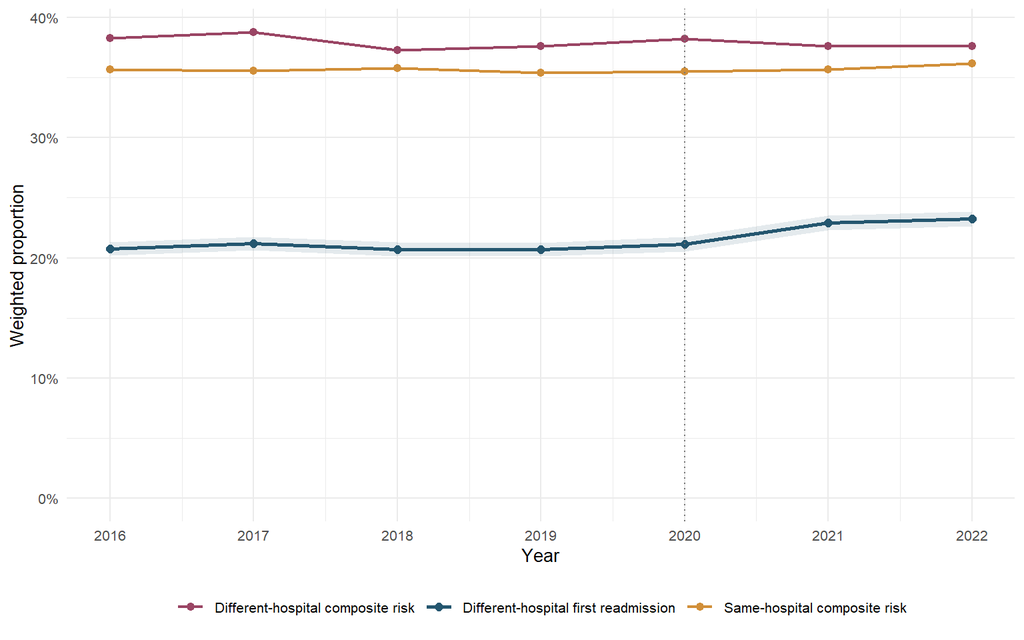

Figure 4: Annual hospital destination and outcome estimates, 2016–2022.

## Supplementary tables

### Table S1. Survey design by year

| Year | Unweighted n | Weighted estimate | Sampling strata | Primary sampling units |
| --- | --- | --- | --- | --- |
| 2016 | 65,372 | 123,068 | 97 | 2,355 |
| 2017 | 75,901 | 137,397 | 97 | 2,454 |
| 2018 | 78,364 | 142,562 | 89 | 2,430 |
| 2019 | 82,010 | 146,524 | 93 | 2,507 |
| 2020 | 70,472 | 126,052 | 100 | 2,539 |
| 2021 | 73,085 | 134,161 | 96 | 2,505 |
| 2022 | 73,782 | 134,526 | 98 | 2,505 |

### Table S2. Full baseline characteristics

Counts of 1–10 are shown as ≤10; * denotes complementary suppression. Percentages use nonmissing survey-weighted denominators.

| Characteristic | Category | Overall | Same hospital | Different hospital | Standardized mean difference |
| --- | --- | --- | --- | --- | --- |
| Age, y | Median (IQR) | 73 (63-83) | 74 (63-83) | 72 (61-81) | -0.159 |
| Sex | Female | 249,243 (48.2%) | 197,774 (48.7%) | 51,469 (46.4%) | 0.046 |
|  | Male | 269,743 (51.8%) | 209,375 (51.3%) | 60,368 (53.6%) |  |
| Expected payer | Medicare | 399,008 (77.1%) | 316,768 (78.0%) | 82,240 (74.0%) | 0.102 |
|  | Medicaid | 58,832 (11.0%) | 43,014 (10.3%) | 15,818 (13.5%) |  |
|  | Private | 41,915 (8.2%) | 32,601 (8.1%) | 9,314 (8.4%) |  |
|  | Other | 18,679 (3.7%) | 14,353 (3.6%) | 4,326 (4.1%) |  |
| ZIP-code income quartile | Quartile 1 (lowest income) | 165,371 (34.1%) | 126,422 (33.3%) | 38,949 (37.3%) | 0.086 |
|  | Quartile 2 | 138,528 (27.5%) | 109,096 (27.6%) | 29,432 (27.1%) |  |
|  | Quartile 3 | 118,574 (22.3%) | 94,689 (22.8%) | 23,885 (20.7%) |  |
|  | Quartile 4 (highest income) | 90,972 (16.0%) | 72,627 (16.3%) | 18,345 (14.8%) |  |
| County urban–rural category | Metro | 447,591 (84.4%) | 355,267 (85.5%) | 92,324 (80.2%) | 0.141 |
|  | Non-metro | 67,757 (15.6%) | 49,673 (14.5%) | 18,084 (19.8%) |  |
| Index-hospital bed size | Small | 94,958 (19.3%) | 67,858 (17.5%) | 27,100 (25.6%) | 0.199 |
|  | Medium | 149,640 (27.9%) | 116,301 (27.7%) | 33,339 (28.8%) |  |
|  | Large | 274,388 (52.8%) | 222,990 (54.8%) | 51,398 (45.5%) |  |
| Hospital location/teaching status | Nonteaching urban | 119,815 (21.5%) | 90,646 (20.7%) | 29,169 (24.3%) | 0.143 |
|  | Teaching urban | 357,007 (68.5%) | 285,236 (69.9%) | 71,771 (63.2%) |  |
|  | Rural | 42,164 (10.0%) | 31,267 (9.4%) | 10,897 (12.4%) |  |
| Index-hospital ownership | Government | 56,042 (10.3%) | 43,099 (10.1%) | 12,943 (11.1%) | 0.108 |
|  | Private nonprofit | 385,110 (75.3%) | 306,434 (76.3%) | 78,676 (71.6%) |  |
|  | Private for-profit | 77,834 (14.4%) | 57,616 (13.6%) | 20,218 (17.4%) |  |
| Annual index-hospital HF volume | Q1 | 4,260 (1.0%) | 2,149 (0.7%) | 2,111 (2.3%) | 0.272 |
|  | Q2 | 31,311 (6.9%) | 19,517 (5.5%) | 11,794 (12.0%) |  |
|  | Q3 | 122,662 (23.7%) | 91,856 (22.7%) | 30,806 (27.3%) |  |
|  | Q4 | 360,753 (68.4%) | 293,627 (71.2%) | 67,126 (58.3%) |  |
| Index length of stay, d | Median (IQR) | 4 (3-7) | 4 (3-7) | 4 (3-7) | -0.006 |
| Index discharge disposition | Routine discharge | * | 195,395 (48.6%) | * | 0.118 |
|  | Other facility | 105,739 (20.6%) | 80,800 (20.1%) | 24,939 (22.4%) |  |
|  | Home health | 160,593 (30.1%) | 130,954 (31.2%) | 29,639 (25.9%) |  |

[output cut: 73 more lines]

### Table S3. Missing data by exposure

Missing values and percentages are shown separately by exposure group. The primary model used complete cases. Readmission after live discharge is not applicable for patients who died during the first readmission; these cells do not represent missing outcome data.

| Variable | Same hospital | Different hospital |
| --- | --- | --- |
| First-readmission hospital | 0 (0.0%) | 0 (0.0%) |
| Primary composite outcome | 0 (0.0%) | 0 (0.0%) |
| Death during first readmission | 0 (0.0%) | 0 (0.0%) |
| Readmission after live discharge | 25,364 (6.2%) | 8,222 (7.4%) |
| Survey weight | 0 (0.0%) | 0 (0.0%) |
| Age, y | 0 (0.0%) | 0 (0.0%) |
| Sex | 0 (0.0%) | 0 (0.0%) |
| Expected payer | 413 (0.1%) | 139 (0.1%) |
| ZIP-code income quartile | 4,315 (1.1%) | 1,226 (1.1%) |
| County urban–rural category | 2,209 (0.5%) | 1,429 (1.3%) |
| Index-hospital bed size | 0 (0.0%) | 0 (0.0%) |
| Hospital location/teaching status | 0 (0.0%) | 0 (0.0%) |
| Index-hospital ownership | 0 (0.0%) | 0 (0.0%) |
| Annual index-hospital HF volume | 0 (0.0%) | 0 (0.0%) |
| Index length of stay, d | 0 (0.0%) | 0 (0.0%) |
| Index discharge disposition | 0 (0.0%) | 0 (0.0%) |
| All Patient Refined Diagnosis Related Groups (APR-DRG) severity | 0 (0.0%) | 0 (0.0%) |
| Days to first readmission | 0 (0.0%) | 0 (0.0%) |
| Earlier hospitalization in calendar year | 0 (0.0%) | 0 (0.0%) |
| First-readmission principal diagnosis | 0 (0.0%) | 0 (0.0%) |
| Elixhauser: Congestive heart failure | 0 (0.0%) | 0 (0.0%) |
| Elixhauser: Cardiac arrhythmias | 0 (0.0%) | 0 (0.0%) |
| Elixhauser: Valvular disease | 0 (0.0%) | 0 (0.0%) |
| Elixhauser: Pulmonary circulation disorders | 0 (0.0%) | 0 (0.0%) |
| Elixhauser: Peripheral vascular disorders | 0 (0.0%) | 0 (0.0%) |
| Elixhauser: Hypertension, uncomplicated | 0 (0.0%) | 0 (0.0%) |
| Elixhauser: Paralysis | 0 (0.0%) | 0 (0.0%) |
| Elixhauser: Other neurologic disorders | 0 (0.0%) | 0 (0.0%) |
| Elixhauser: Chronic pulmonary disease | 0 (0.0%) | 0 (0.0%) |
| Elixhauser: Diabetes, uncomplicated | 0 (0.0%) | 0 (0.0%) |
| Elixhauser: Diabetes, complicated | 0 (0.0%) | 0 (0.0%) |
| Elixhauser: Hypothyroidism | 0 (0.0%) | 0 (0.0%) |
| Elixhauser: Renal failure | 0 (0.0%) | 0 (0.0%) |
| Elixhauser: Liver disease | 0 (0.0%) | 0 (0.0%) |
| Elixhauser: Peptic ulcer disease | 0 (0.0%) | 0 (0.0%) |
| Elixhauser: AIDS/HIV | 0 (0.0%) | 0 (0.0%) |
| Elixhauser: Lymphoma | 0 (0.0%) | 0 (0.0%) |
| Elixhauser: Metastatic cancer | 0 (0.0%) | 0 (0.0%) |
| Elixhauser: Solid tumor without metastasis | 0 (0.0%) | 0 (0.0%) |
| Elixhauser: Rheumatoid arthritis/collagen vascular disease | 0 (0.0%) | 0 (0.0%) |
| Elixhauser: Coagulopathy | 0 (0.0%) | 0 (0.0%) |
| Elixhauser: Obesity | 0 (0.0%) | 0 (0.0%) |
| Elixhauser: Weight loss | 0 (0.0%) | 0 (0.0%) |
| Elixhauser: Fluid and electrolyte disorders | 0 (0.0%) | 0 (0.0%) |
| Elixhauser: Blood loss anemia | 0 (0.0%) | 0 (0.0%) |
| Elixhauser: Deficiency anemia | 0 (0.0%) | 0 (0.0%) |
| Elixhauser: Alcohol abuse | 0 (0.0%) | 0 (0.0%) |
| Elixhauser: Drug abuse | 0 (0.0%) | 0 (0.0%) |
| Elixhauser: Psychoses | 0 (0.0%) | 0 (0.0%) |
| Elixhauser: Depression | 0 (0.0%) | 0 (0.0%) |
| Elixhauser: Hypertension, complicated | 0 (0.0%) | 0 (0.0%) |

### Table S3b. Complete-case inclusion by year and exposure

Counts show eligible first readmissions, complete-case inclusion, and loss from the primary model by year and exposure group.

| Year | First-readmission hospital | Eligible cohort, unweighted n | Included in complete-case model, unweighted n | Excluded for missing covariates, unweighted n | Included, weighted estimate |
| --- | --- | --- | --- | --- | --- |
| 2016 | Same hospital | 51,617 | 50,854 | 763 | 96,167 |
| 2016 | Different hospital | 13,755 | 13,516 | 239 | 25,110 |
| 2017 | Same hospital | 59,784 | 58,867 | 917 | 106,742 |
| 2017 | Different hospital | 16,117 | 15,758 | 359 | 28,533 |
| 2018 | Same hospital | 62,128 | 61,053 | 1,075 | 111,185 |
| 2018 | Different hospital | 16,236 | 15,855 | 381 | 28,913 |
| 2019 | Same hospital | 64,991 | 63,819 | 1,172 | 114,339 |
| 2019 | Different hospital | 17,019 | 16,552 | 467 | 29,636 |
| 2020 | Same hospital | 55,572 | 54,528 | 1,044 | 97,729 |
| 2020 | Different hospital | 14,900 | 14,469 | 431 | 26,004 |
| 2021 | Same hospital | 56,346 | 55,298 | 1,048 | 101,661 |
| 2021 | Different hospital | 16,739 | 16,274 | 465 | 30,024 |
| 2022 | Same hospital | 56,711 | 55,820 | 891 | 101,812 |
| 2022 | Different hospital | 17,071 | 16,630 | 441 | 30,583 |

### Table S4. Model populations and specification

| Model | Outcome | Analysis population, unweighted n | Analysis population, weighted estimate | Design degrees of freedom | Model converged | Continuous covariate specification |
| --- | --- | --- | --- | --- | --- | --- |
| Primary survey-weighted logistic regression | Primary composite | 509,293 | 928,438 | 14,107 | Yes | Age: 47/68/79/90; log1p(index LOS): 0.6931472/1.386294/1.94591/2.772589 (5th/35th/65th/95th percentiles) |
| Primary survey-weighted logistic regression | In-hospital death | 509,293 | 928,438 | 14,107 | Yes | Age: 47/68/79/90; log1p(index LOS): 0.6931472/1.386294/1.94591/2.772589 (5th/35th/65th/95th percentiles) |
| Primary survey-weighted logistic regression | Readmission after live discharge | 476,177 | 869,135 | 13,992 | Yes | Age: 47/68/79/90; log1p(index LOS): 0.6931472/1.386294/1.94591/2.772589 (5th/35th/65th/95th percentiles) |
| Primary survey-weighted logistic regression | HF-coded subsequent readmission | 476,177 | 869,135 | 13,992 | Yes | Age: 47/68/79/90; log1p(index LOS): 0.6931472/1.386294/1.94591/2.772589 (5th/35th/65th/95th percentiles) |
| Primary survey-weighted logistic regression | Non-elective-coded subsequent readmission | 476,068 | 868,886 | 13,991 | Yes | Age: 47/68/79/90; log1p(index LOS): 0.6931472/1.386294/1.94591/2.772589 (5th/35th/65th/95th percentiles) |

### Table S5. Exposure coefficients

Exposure odds ratios from the five adjusted outcome models are shown with 95% confidence intervals.

| Outcome | Exposure odds ratio (95% CI) | P value |
| --- | --- | --- |
| Primary composite | 1.09, 95% CI 1.08–1.11 | P < 0.001 |
| In-hospital death | 1.23, 95% CI 1.19–1.27 | P < 0.001 |
| Readmission after live discharge | 1.06, 95% CI 1.04–1.08 | P < 0.001 |
| HF-coded subsequent readmission | 1.02, 95% CI 0.99–1.04 | P = 0.155 |
| Non-elective-coded subsequent readmission | 1.05, 95% CI 1.03–1.06 | P < 0.001 |

### Table S6. Overlap-weighting covariate balance

| Covariate | Before weighting, standardized difference | After overlap weighting, standardized difference |
| --- | --- | --- |
| Discharge year | 0.040 | 0.000 |
| Age, y | -0.154 | -0.000 |
| Sex | 0.043 | 0.000 |
| Expected payer | 0.094 | 0.000 |
| ZIP-code income quartile | 0.078 | 0.000 |
| County urban–rural category | 0.140 | 0.000 |
| Index-hospital bed size | 0.201 | 0.000 |
| Hospital location/teaching status | 0.145 | 0.000 |
| Index-hospital ownership | 0.108 | 0.000 |
| Annual index-hospital HF volume | 0.273 | 0.000 |
| Index length of stay, d | -0.006 | -0.004 |
| Index discharge disposition | 0.115 | 0.000 |
| All Patient Refined Diagnosis Related Groups (APR-DRG) severity | 0.049 | 0.000 |
| Days to first readmission | 0.037 | 0.000 |
| Earlier hospitalization in calendar year | 0.019 | 0.000 |
| Elixhauser: Cardiac arrhythmias | 0.064 | 0.000 |
| Elixhauser: Valvular disease | 0.024 | 0.000 |
| Elixhauser: Pulmonary circulation disorders | 0.032 | 0.000 |
| Elixhauser: Peripheral vascular disorders | 0.021 | 0.000 |
| Elixhauser: Hypertension, uncomplicated | 0.010 | 0.000 |
| Elixhauser: Paralysis | 0.009 | 0.000 |
| Elixhauser: Other neurologic disorders | 0.019 | 0.000 |
| Elixhauser: Chronic pulmonary disease | 0.028 | 0.000 |
| Elixhauser: Diabetes, uncomplicated | 0.029 | 0.000 |
| Elixhauser: Diabetes, complicated | 0.019 | 0.000 |
| Elixhauser: Hypothyroidism | 0.046 | 0.000 |
| Elixhauser: Renal failure | 0.049 | 0.000 |
| Elixhauser: Liver disease | 0.025 | 0.000 |
| Elixhauser: Peptic ulcer disease | 0.004 | 0.000 |
| Elixhauser: AIDS/HIV | 0.018 | 0.000 |
| Elixhauser: Lymphoma | 0.017 | 0.000 |
| Elixhauser: Metastatic cancer | 0.011 | 0.000 |
| Elixhauser: Solid tumor without metastasis | 0.017 | 0.000 |
| Elixhauser: Rheumatoid arthritis/collagen vascular disease | 0.019 | 0.000 |
| Elixhauser: Coagulopathy | 0.001 | 0.000 |
| Elixhauser: Obesity | 0.016 | 0.000 |
| Elixhauser: Weight loss | 0.001 | 0.000 |
| Elixhauser: Fluid and electrolyte disorders | 0.003 | 0.000 |
| Elixhauser: Blood loss anemia | 0.006 | 0.000 |
| Elixhauser: Deficiency anemia | 0.005 | 0.000 |
| Elixhauser: Alcohol abuse | 0.031 | 0.000 |
| Elixhauser: Drug abuse | 0.085 | 0.000 |
| Elixhauser: Psychoses | 0.045 | 0.000 |
| Elixhauser: Depression | 0.016 | 0.000 |
| Elixhauser: Hypertension, complicated | 0.037 | 0.000 |
| Age spline basis 1 | -0.027 | -0.000 |
| Age spline basis 2 | -0.076 | -0.000 |
| Age spline basis 3 | -0.095 | 0.000 |
| Index LOS spline basis 1 | -0.052 | 0.000 |
| Index LOS spline basis 2 | -0.034 | -0.000 |
| Index LOS spline basis 3 | 0.013 | 0.000 |

### Table S7. Annual estimates

Annual destination proportions, outcome risks, and risk differences are survey-weighted and unadjusted; P values for trend are reported in the text.

| Year | Different-hospital first readmission | Same-hospital outcome risk | Different-hospital outcome risk | Risk difference |
| --- | --- | --- | --- | --- |
| 2016 | 20.7% (95% CI, 20.2–21.3) | 35.7% | 38.2% | +2.59 percentage points (95% CI, +1.51 to +3.68) |
| 2017 | 21.2% (95% CI, 20.6–21.8) | 35.6% | 38.8% | +3.21 percentage points (95% CI, +2.29 to +4.14) |
| 2018 | 20.7% (95% CI, 20.1–21.3) | 35.8% | 37.3% | +1.51 percentage points (95% CI, +0.59 to +2.42) |
| 2019 | 20.7% (95% CI, 20.1–21.3) | 35.4% | 37.6% | +2.24 percentage points (95% CI, +1.35 to +3.12) |
| 2020 | 21.2% (95% CI, 20.6–21.8) | 35.5% | 38.2% | +2.72 percentage points (95% CI, +1.78 to +3.67) |
| 2021 | 22.9% (95% CI, 22.3–23.5) | 35.6% | 37.6% | +1.98 percentage points (95% CI, +1.07 to +2.88) |
| 2022 | 23.2% (95% CI, 22.6–23.9) | 36.1% | 37.6% | +1.44 percentage points (95% CI, +0.52 to +2.36) |

### Table S8. Diagnosis definitions

| Definition | Code system | Codes |
| --- | --- | --- |
| Heart failure | ICD-10-CM principal diagnosis | I50*, I11.0, I13.0, I13.2, I09.81 |
| Other cardiovascular | ICD-10-CM principal diagnosis | I00-I99 excluding heart-failure codes above |
| Infection/sepsis | ICD-10-CM principal diagnosis | A00-B99; R65.2* |
| Renal/AKI | ICD-10-CM principal diagnosis | N00-N39 |
| Respiratory/COPD | ICD-10-CM principal diagnosis | J00-J99 (including pneumonia); R06* |
| GI/bleeding | ICD-10-CM principal diagnosis | K00-K95; D50-D64 |
| Other | ICD-10-CM principal diagnosis | All remaining principal diagnoses |

### Table S9. E-value sensitivity

The E-value summarizes the minimum association strength an unmeasured confounder would need with both exposure and outcome, conditional on measured covariates, to explain the observed risk ratio under its assumptions. It does not establish causality.

| Primary risk ratio | E-value | E-value for confidence limit |
| --- | --- | --- |
| 1.056 | 1.30 | 1.27 |

## Statements

Software: R version 4.6.1, survey package version 4.5, and Quarto version 1.10.19.

Data use: HCUP NRD; deidentified; analyses comply with the HCUP Data Use Agreement; cells ≤10 suppressed.

Ethics, funding, and author statements: to be completed by the authors.

## References

1. McAlister FA, Youngson E, Kaul P. Patients with heart failure readmitted to the original hospital have better outcomes than those readmitted elsewhere. *J Am Heart Assoc*. 2017;6(5):e004892. doi:10.1161/JAHA.116.004892.
2. Lahewala S, Arora S, Tripathi B, Panaich S, Kumar V, Patel N, et al. Heart failure: same-hospital vs. different-hospital readmission outcomes. *Int J Cardiol*. 2019;278:186–191. doi:10.1016/j.ijcard.2018.12.043.
3. Snow K, Galaviz K, Turbow S. Patient outcomes following interhospital care fragmentation: a systematic review. *J Gen Intern Med*. 2020;35(5):1550–1558. doi:10.1007/s11606-019-05366-z.
4. Thandra A, Balakrishna AM, Walters RW, Alugubelli N, Koripalli VS, Alla VM. Trends in and predictors of multiple readmissions following heart failure hospitalization: a nationwide analysis from the United States. *Am J Med Sci*. 2023;365(2):145–151. doi:10.1016/j.amjms.2022.09.006.
5. Turbow S, Walker T, Culler S, Ali MK. Care fragmentation and readmission mortality and length of stay before and during the COVID-19 pandemic: data from the National Readmissions Database, 2018–2020. *BMC Health Serv Res*. 2024;24:622. doi:10.1186/s12913-024-11073-1.